# The Penn World Tables

### Loading packages etc.

```r
rm(list = ls())
library(reshape2)
library(base)
library(ggplot2)
library(grid)
library(scales)
library(stringr)
library(tidyverse)
library(pwt10)

# should graphs be exported to pdf
export_pdf <- FALSE
```

### Accessing the Penn World Tables

The most important package used here is `pwt10`. It contains data from the Penn World Tables. The Penn World Tables (PWT) cover important cross country data on macroeconomic performance, like GDP, labor input, the capital stock as well as labor and capital compensation. You can find an overview of the [Penn World Tables here](https://www.rug.nl/ggdc/productivity/pwt/). Downloading the Excel sheet version is the easiest way to inspect the different variables in the PWT dataset. We will use these tables in the following to study some growth facts for the United States. To get a first impression of the Penn World Tables, we can load and inspect them with the following statement:

```r
data("pwt10.01")
View(pwt10.01)
```

As a next step, we want to study the macroeconomic performance of post-War United States. To this end, we extract a sub-dataset that only contains US data.

```r
pwt_sub <- subset(pwt10.01, isocode=="USA")
```

### Increasing economic performance: growth in GDP

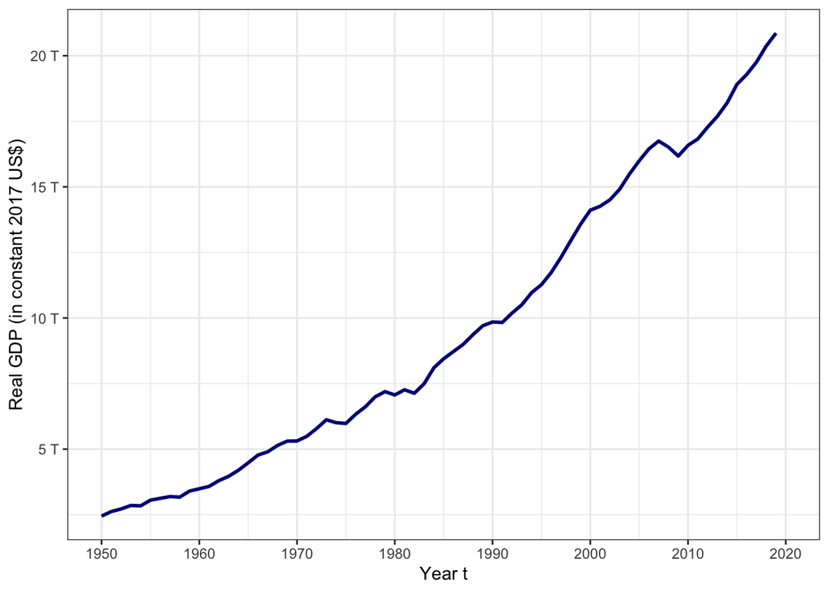

```r
myplot <- ggplot(data = pwt_sub) +
  geom_line(aes(x=year, y=rgdpe), color="darkblue", linewidth=1) +
  coord_cartesian(xlim=c(1950, 2020)) +
  scale_x_continuous(breaks=seq(1950, 2020, 10)) +
  scale_y_continuous(labels = unit_format(unit = "T", scale = 1e-6)) +
  labs(x = "Year t",
       y = "Real GDP (in constant 2017 US$)") +
  theme_bw()

# print the plot
print(myplot)
```

GDP grows steadily over time. We can see a bit of up and down movements (especially the consequences of the financial crisis in 2008). Yet, from a long horizon perspective, GDP is growing steadily.

### Potential drivers of GDP growth I: the labor force

But what are the drivers behind GDP growth? A first suspect would be the size of the labor force, i.e. the number of workers that contribute to production. The idea is simple: the more workers there are, the more can be produced.

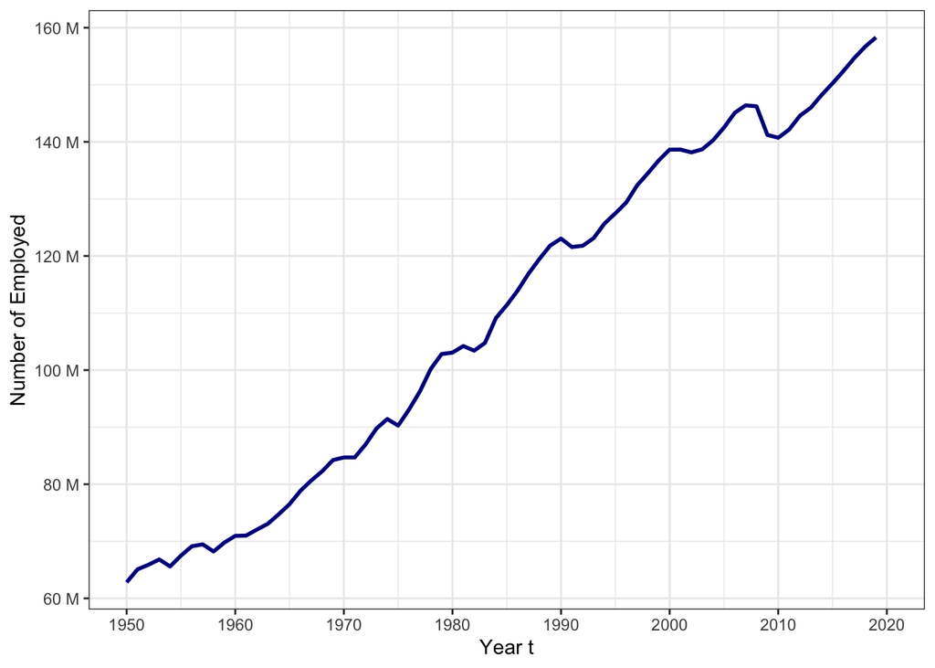

```r
myplot <- ggplot(data = pwt_sub) +
  geom_line(aes(x=year, y=emp), color="darkblue", linewidth=1) +
  coord_cartesian(xlim=c(1950, 2020)) +
  scale_x_continuous(breaks=seq(1950, 2020, 10)) +
  scale_y_continuous(labels = unit_format(unit = "M", scale = 1)) +
  labs(x = "Year t",
       y = "Number of Employed") +
  theme_bw()

# print the plot
print(myplot)
```

In fact, the workforce in the US has grown steadily over time as well, and we find some nice correlations between the growth of the workforce and GDP (see e.g. the financial crises). However, it is not only the number of workers that matters for an economy’s output, but also how much they work. In a next step, we therefore look at hours per worker and how these hours evolved over time.

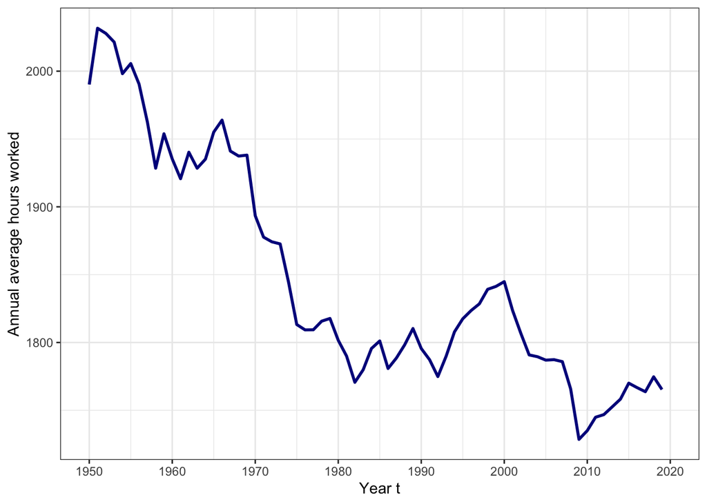

```r
myplot <- ggplot(data = pwt_sub) +
  geom_line(aes(x=year, y=avh), color="darkblue", linewidth=1) +
  coord_cartesian(xlim=c(1950, 2020)) +
  scale_x_continuous(breaks=seq(1950, 2020, 10)) +
  labs(x = "Year t",
       y = "Annual average hours worked") +
  theme_bw()

# print the plot
print(myplot)
```

The average worker provided about 2000 hours of labor supply in the 1950s and 1960s. Assuming a 48 week year, this amounts to almost 42 hours a week. Note that this is a remarkable number, as the number of workers also contains part-time employees. Hence, a full-time work-schedule approximately consisted of a 50 hours work week. This has changed somewhat over time, especially in the 1970s where (in several countries) workers and unions bargained a work hours reduction down to about 40 hours. This essentially meant a free Saturday for many employees. Taken together, we can calculate the **total number of work hours provided by workers** in each year simply as the product between the number of workers and average hours. This is shown in the following graph.

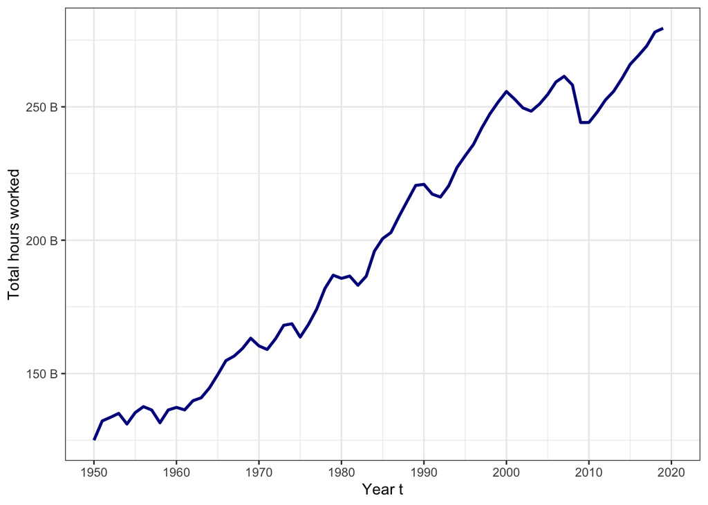

```r
# calculate total hours worked
pwt_sub$total_hours <- pwt_sub$emp*pwt_sub$avh

# generate plot
myplot <- ggplot(data = pwt_sub) +
  geom_line(aes(x=year, y=total_hours), color="darkblue", linewidth=1) +
  coord_cartesian(xlim=c(1950, 2020)) +
  scale_x_continuous(breaks=seq(1950, 2020, 10)) +
  scale_y_continuous(labels = unit_format(unit = "B", scale = 1e-3)) +
  labs(x = "Year t",
       y = "Total hours worked") +
  theme_bw()

# print the plot
print(myplot)
```

Finally, next to the amount of labor provided to the production sector, it also matters how productive labor input is. A more productive worker may produce the same amount of goods or services in less time, hence, create more product on one working day. The following graph shows an index of workers’ labor productivity or human capital. The index is scale free, meaning that we can compare it across different periods of time, but it has no direct monetary equivalent.

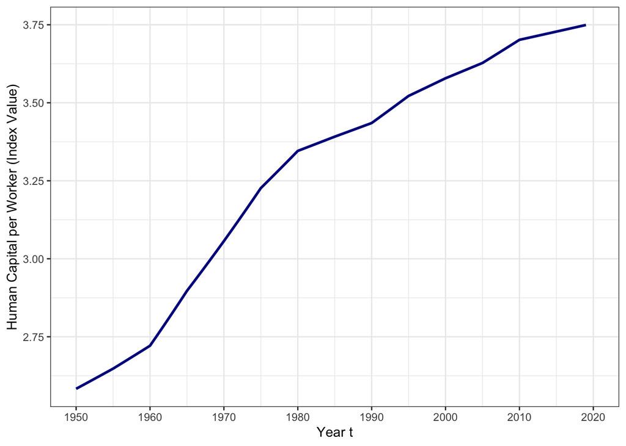

```r
myplot <- ggplot(data = pwt_sub) +
  geom_line(aes(x=year, y=hc), color="darkblue", linewidth=1) +
  coord_cartesian(xlim=c(1950, 2020)) +
  scale_x_continuous(breaks=seq(1950, 2020, 10)) +
  labs(x = "Year t",
       y = "Human Capital per Worker (Index Value)") +
  theme_bw()

# print the plot
print(myplot)
```

### Potential drivers of GDP growth II: capital input

The production process usually is organized by two inputs: labor on the one hand and capital (meaning machinery, equipment, structures, etc.) on the other. The following graph plots the US economy’s aggregate capital stock over time.

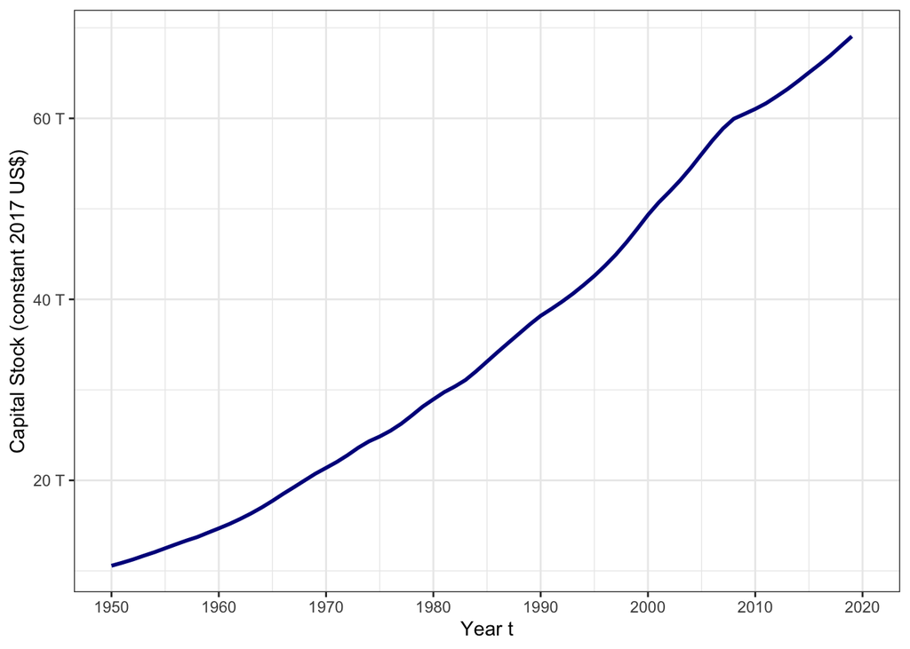

```r
myplot <- ggplot(data = pwt_sub) +
  geom_line(aes(x=year, y=rnna), color="darkblue", linewidth=1) +
  coord_cartesian(xlim=c(1950, 2020)) +
  scale_x_continuous(breaks=seq(1950, 2020, 10)) +
  scale_y_continuous(labels = unit_format(unit = "T", scale = 1e-6)) +
  labs(x = "Year t",
       y = "Capital Stock (constant 2017 US$)") +
  theme_bw()

# print the plot
print(myplot)
```

There are two things to note here. First, the capital stock (like labor input) is growing steadily over time. Second, the capital stock is substatial and it is much larger than GDP (by around a factor of three to four). Note that the above graph contains the entire capital stock of the economy, which consists of

- residential and non-residential structures
- machinery and equipment
- transport equipment
- and other assets.

We could be a bit more precise by only looking at the corporate capital stock, thereby excluding residential structures. But this would involve studying another dataset (for example the National Income and Product Accounts), which would be too much for this lecture.